# Shooting Data

Josh Garvey

2022-09-07

## Step 1: Obtaining Data

First thing I will do is read in the shooting data from the web.

```r
url_in <- "https://data.cityofnewyork.us/api/views/833y-fsy8/rows.csv?accessType=DOWNLOAD"
shooting_data <- read_csv(url_in)
```

## Step 2: Tidy Up the data

Now that I have data in the shooting_data variable I can work on tidying it up. I would like to look at the amount of deaths/shooting/precinct. I left in victim and perpetrator sex and race in case I want to start pulling those factors in as well

```r
sub_shoot = subset(shooting_data, select = -c(INCIDENT_KEY,
                                              OCCUR_DATE,
                                              OCCUR_TIME,
                                              BORO,
                                              JURISDICTION_CODE,
                                              LOCATION_DESC,
                                              X_COORD_CD,
                                              Y_COORD_CD,
                                              VIC_AGE_GROUP,
                                              Latitude,
                                              Longitude,
                                              Lon_Lat
                                              ))
# columns removed
sub_shoot
```

```
## # A tibble: 25,596 × 7
##    PRECINCT STATISTICAL_MURDER_FLAG PERP_AGE_G…¹ PERP_…² PERP_…³ VIC_SEX VIC_R…⁴
##       <dbl> <lgl>                   <chr>        <chr>   <chr>   <chr>   <chr>
##  1       52 TRUE                    <NA>         <NA>    <NA>    F       BLACK …
##  2      106 FALSE                   <NA>         <NA>    <NA>    M       WHITE
##  3       42 TRUE                    <NA>         <NA>    <NA>    M       BLACK
##  4       52 FALSE                   <NA>         <NA>    <NA>    M       BLACK
##  5       34 FALSE                   <NA>         <NA>    <NA>    M       BLACK …
##  6       75 TRUE                    25-44        M       BLACK … M       WHITE …
##  7       32 FALSE                   25-44        M       BLACK   M       BLACK
##  8       26 FALSE                   <NA>         <NA>    <NA>    M       BLACK
##  9       41 TRUE                    25-44        M       BLACK   M       BLACK …
## 10       67 FALSE                   <NA>         <NA>    <NA>    M       BLACK
## # … with 25,586 more rows, and abbreviated variable names ¹PERP_AGE_GROUP,
## #   ²PERP_SEX, ³PERP_RACE, ⁴VIC_RACE
```

```r
# summary
summary(sub_shoot)
```

```
##     PRECINCT      STATISTICAL_MURDER_FLAG PERP_AGE_GROUP       PERP_SEX
##  Min.   :  1.00   Mode :logical           Length:25596       Length:25596
##  1st Qu.: 44.00   FALSE:20668             Class :character   Class :character
##  Median : 69.00   TRUE :4928              Mode  :character   Mode  :character
##  Mean   : 65.87
##  3rd Qu.: 81.00
##  Max.   :123.00
##   PERP_RACE           VIC_SEX            VIC_RACE
##  Length:25596       Length:25596       Length:25596
##  Class :character   Class :character   Class :character
##  Mode  :character   Mode  :character   Mode  :character
##
##
##
```

There are some null points in the data set. I plan on throwing those data points out if they are part of an analysis.

## Step 3: Visualize the Data and Analyze

With the data parsed down I can start to explore different factors leading to shooting deaths to try and find correlations. To start with I will select the columns for whether or not there was a death, and what precinct it occured in.

```r
deaths = subset(sub_shoot, select = c(PRECINCT, STATISTICAL_MURDER_FLAG))
summary(deaths)
```

```
##     PRECINCT      STATISTICAL_MURDER_FLAG
##  Min.   :  1.00   Mode :logical
##  1st Qu.: 44.00   FALSE:20668
##  Median : 69.00   TRUE :4928
##  Mean   : 65.87
##  3rd Qu.: 81.00
##  Max.   :123.00
```

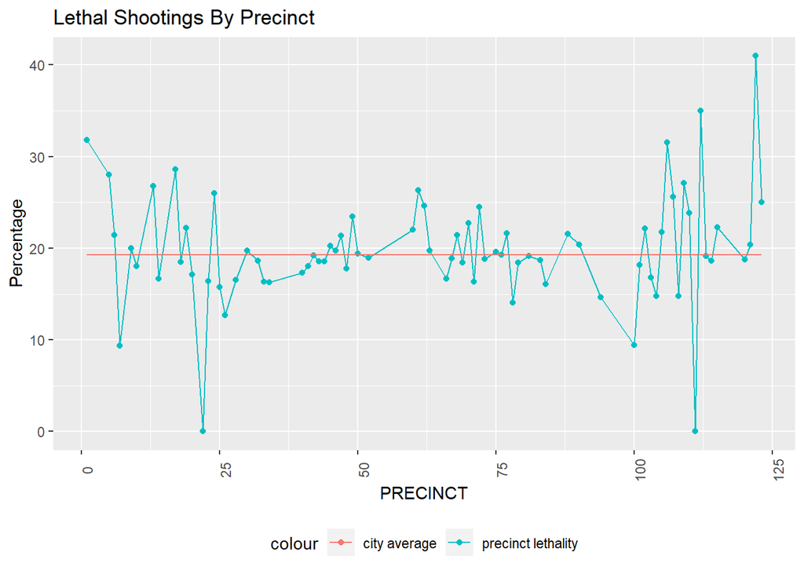

```r
# Total shootings and percentage that are lethal (a baseline for the area)
nLethal = sum(!deaths[2])
Lethal = sum(deaths[2])
total_shootings = Lethal + nLethal
percent_lethal_total = (Lethal/total_shootings)*100

# Group the data to be graphed
deaths_by_precinct <- deaths %>%
  group_by(PRECINCT) %>%
  summarize(num_deaths = sum(STATISTICAL_MURDER_FLAG),
            shootings = sum(STATISTICAL_MURDER_FLAG)+sum(!STATISTICAL_MURDER_FLAG)) %>%
  mutate(perc_lethal = (num_deaths / shootings) *100) %>%
  ungroup()

# Graph the lethal percentages by precinct
deaths_by_precinct %>%
  ggplot(aes(x = PRECINCT, y = perc_lethal)) +
  geom_line(aes(color = "precinct lethality")) +
  geom_point(aes(color = "precinct lethality")) +
  geom_line(aes(y = percent_lethal_total, color = "city average")) +
  theme(legend.position = "bottom",
        axis.text.x = element_text(angle = 90)) +
  labs(title = "Lethal Shootings By Precinct", y = "Percentage")
```

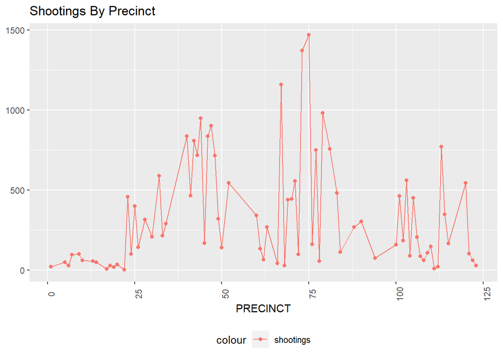

```r
# Graph number of shootings versus total shooting to see if there is a trigger happy precinct
shootings_by_precinct <- deaths %>%
  group_by(PRECINCT) %>%
  summarize(num_shootings = sum(STATISTICAL_MURDER_FLAG)+sum(!STATISTICAL_MURDER_FLAG)) %>%
  ungroup()

shootings_by_precinct %>%
  ggplot(aes(x = PRECINCT, y = num_shootings)) +
  geom_line(aes(color = "shootings")) +
  geom_point(aes(color = "shootings")) +
  theme(legend.position = "bottom",
        axis.text.x = element_text(angle = 90)) +
  labs(title = "Shootings By Precinct", y = NULL)
```

## Step 4: Sources of Bias

I could try to mitigate by picking a few columns for data to hopefully give me an idea when something is an outlier. This is going to be hard to pick arbitrarily. Alternatively, I can accept that there is bias in the study and append a synopsis of how I got my results to the report so others can decide if its worthy of their use.